# Reproducible Research- Peer-graded Assignment: Course Project 1

Steve Ellison

December 1, 2019

## Reproducible Research-graded Assignment: Course Project 1

This assignment makes use of data from a personal activity monitoring device. This device collects data at 5 minute intervals through out the day. The data consists of two months of data from an anonymous individual collected during the months of October and November, 2012 and include the number of steps taken in 5 minute intervals each day. Read statement and summary of initial file:

```r
act1 <- read.csv("activity.csv", header=TRUE)
summary(act1)
```

```
##      steps                date          interval
##  Min.   :  0.00   2012-10-01:  288   Min.   :   0.0
##  1st Qu.:  0.00   2012-10-02:  288   1st Qu.: 588.8
##  Median :  0.00   2012-10-03:  288   Median :1177.5
##  Mean   : 37.38   2012-10-04:  288   Mean   :1177.5
##  3rd Qu.: 12.00   2012-10-05:  288   3rd Qu.:1766.2
##  Max.   :806.00   2012-10-06:  288   Max.   :2355.0
##  NA's   :2304     (Other)   :15840
```

From the above we see 2304 NA values, so we need to impute the missing values. There are lots of ways to do it. I checked MICE and that was interesting although i did not fully understand what it was doing, so i chose instead to use the IMPUTE statement that is part of HMISC package and inmpute the MEAN for missing values. Also I used LUBRIDATE package to format the date into DOW (day of week) for reporting purposes. Here is the code i used to transform act1 :

```r
library(Hmisc)
act1$steps2 <- with(act1, impute(steps, mean))

library(lubridate)
act1$dow<-wday(act1$date,label=TRUE)

act1$dayType <- ifelse(weekdays(as.Date(act1$date)) == "Saturday" | weekdays(as.Date(act1$date)) == "Sunday", "weekend", "weekday")
```

New summary of act1. Imputed column ‘steps2’ does not have any missing values:

```r
summary(act1)
```

```
##
##  2304 values imputed to 37.3826
```

```
##      steps                date          interval          steps2
##  Min.   :  0.00   2012-10-01:  288   Min.   :   0.0   Min.   :  0.00
##  1st Qu.:  0.00   2012-10-02:  288   1st Qu.: 588.8   1st Qu.:  0.00
##  Median :  0.00   2012-10-03:  288   Median :1177.5   Median :  0.00
##  Mean   : 37.38   2012-10-04:  288   Mean   :1177.5   Mean   : 37.38
##  3rd Qu.: 12.00   2012-10-05:  288   3rd Qu.:1766.2   3rd Qu.: 37.38
##  Max.   :806.00   2012-10-06:  288   Max.   :2355.0   Max.   :806.00
##  NA's   :2304     (Other)   :15840
##   dow         dayType
##  Sun:2304   Length:17568
##  Mon:2592   Class :character
##  Tue:2592   Mode  :character
##  Wed:2592
##  Thu:2592
##  Fri:2592
##  Sat:2304
```

The first part of what follows shows the views without imputed values. Second part is views with the imputed values. I conclude with an assessment of the impact of non-imputed vs imputed views.

Note: Instead of creating two datasets as indicated in the instructions I chose to simpy add column “steps2” with the imputed values to the original dataset.

## Views WITHOUT Imputed Missing Values

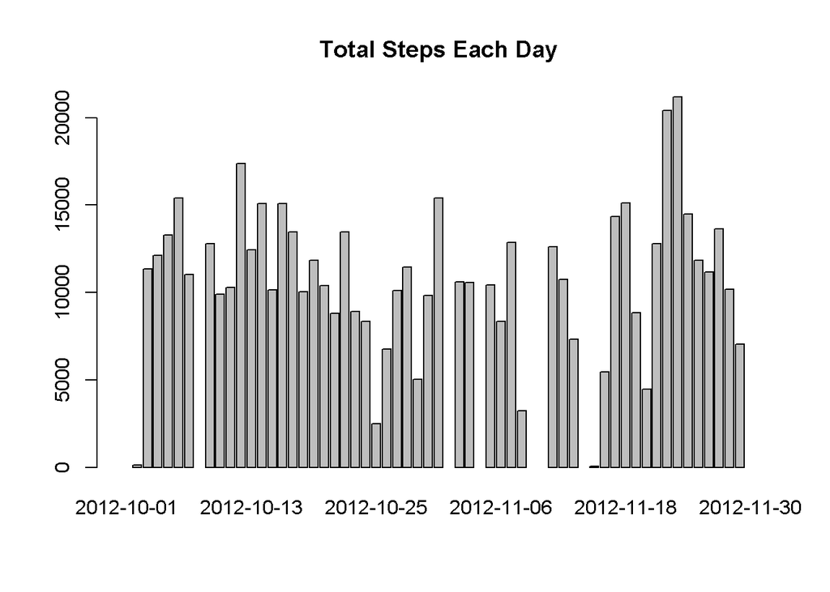

```r
barplot(with(act1,tapply(steps, date, sum)),main="Total Steps Each Day")
```

Mean number of steps each day of week:

```r
with(act1,round(tapply(steps,dow, mean,na.rm=TRUE),digits=2))
```

```
##   Sun   Mon   Tue   Wed   Thu   Fri   Sat
## 42.63 34.63 31.07 40.94 28.52 42.92 43.53
```

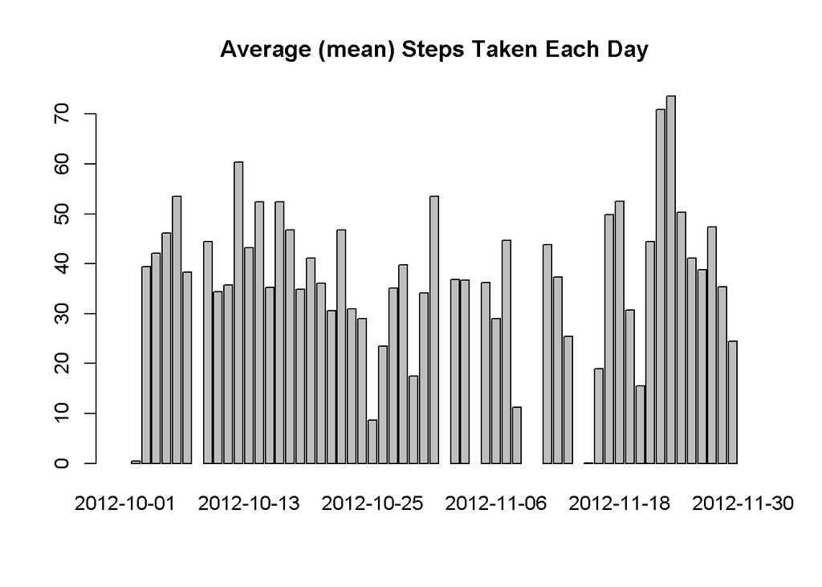

```r
barplot(with(act1,round(tapply(steps, date, mean),digits=2)),main="Average (mean) Steps Taken Each Day")
```

```r
avg_int<-with(act1,round(tapply(steps, interval, mean)), digits=2)
df<-data.frame(avg_int)
subset(df,avg_int==max(avg_int))
```

```
## [1] avg_int
## <0 rows> (or 0-length row.names)
```

Weekend vs Weekday comparison:

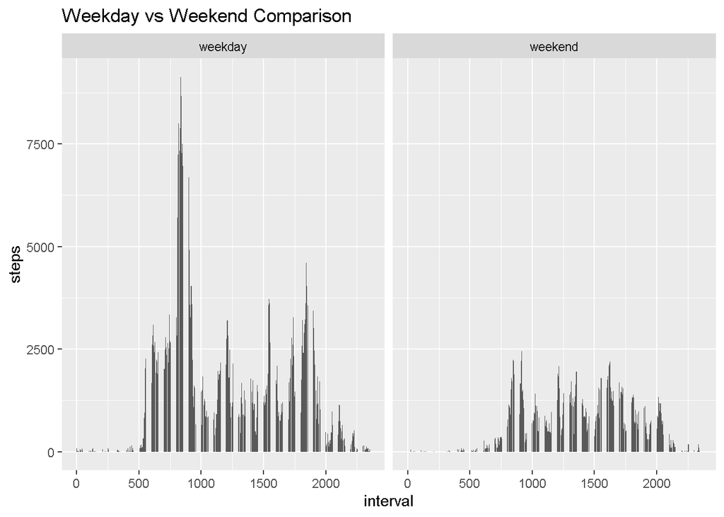

```r
g<-ggplot(act1,aes(interval,steps))+geom_col()+facet_grid(.~dayType)+ggtitle("Weekday vs Weekend Comparison")
g
```

## Views WITH Imputed Missing Values

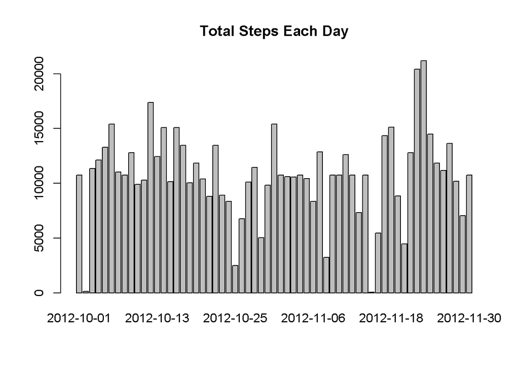

```r
barplot(with(act1,tapply(steps2, date, sum)),main="Total Steps Each Day")
```

Mean number of steps each day of week:

```r
with(act1,round(tapply(steps2, dow, mean),digits=2))
```

```
##   Sun   Mon   Tue   Wed   Thu   Fri   Sat
## 41.97 35.25 31.07 40.54 29.50 41.69 42.76
```

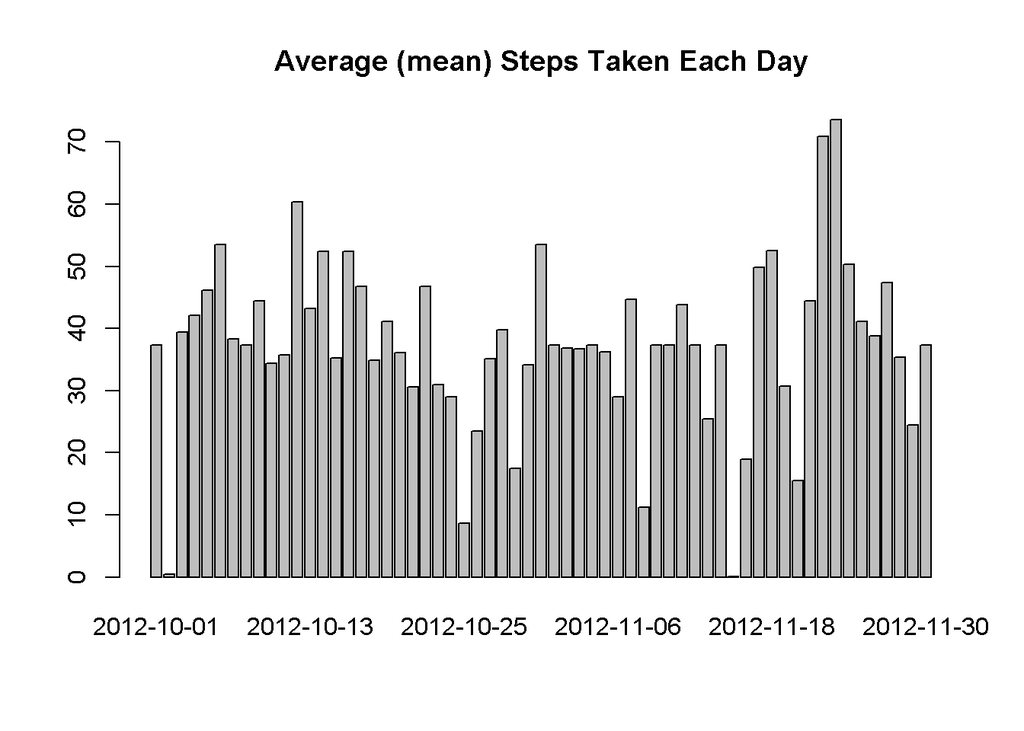

```r
barplot(with(act1,round(tapply(steps2, date, mean),digits=2)),main="Average (mean) Steps Taken Each Day")
```

The 5-minute interval that, on average, contains the maximum number of steps:

```r
avg_int<-with(act1,round(tapply(steps2, interval, mean)), digits=2)
df<-data.frame(avg_int)
subset(df,avg_int==max(avg_int))
```

```
##     avg_int
## 835     184
```

Weekend vs Weekday comparison:

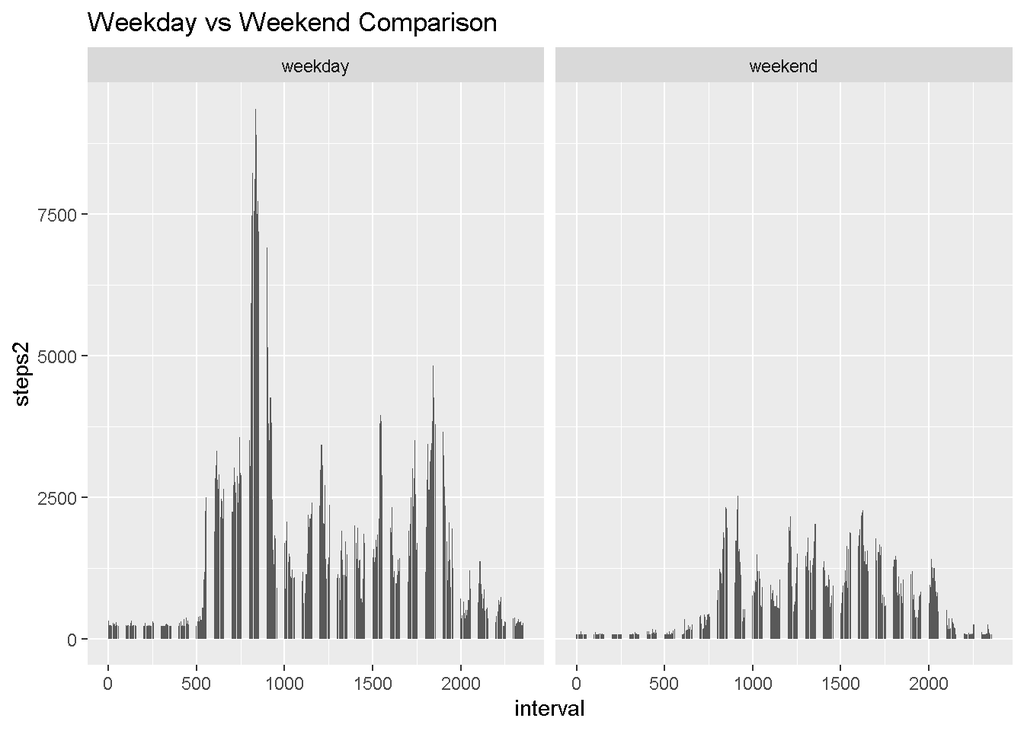

```r
g<-ggplot(act1,aes(interval,steps2))+geom_col()+facet_grid(.~dayType)+ggtitle("Weekday vs Weekend Comparison")
g
```

## Assessment of Impact of Imputed Values

Mean Steps per interval per day WITHOUT imputed Values:

Sun Mon Tue Wed Thu Fri Sat  
42.63 34.63 31.07 40.94 28.52 42.92 43.53

Mean Steps per interval per day WITH imputed Values:

Sun Mon Tue Wed Thu Fri Sat  
41.97 35.25 31.07 40.54 29.50 41.69 42.76